# Fertilizer Recommendations

DA5030 / kNN Classification

Zoe Chow

Summer 2025

## Part A: Configuration

### Load Packages

```r
library(dplyr)
library(caret)
library(kableExtra)
library(class)
library(gmodels)
```

## Part B: Load Data

To load the data, I saved the urls in the variables *train* and *validation*. I then used the function `read.csv()` with the parameters `stringsAsFactors = F` and `header = T` to open the data from the urls.

```r
train <- "https://s3.us-east-2.amazonaws.com/artificium.us/datasets/fertilizer-recommendation.csv"
train_df <- read.csv(train, stringsAsFactors = F, header = T)

validation <- "https://s3.us-east-2.amazonaws.com/artificium.us/datasets/fertilizer-recommendation-validation.csv"
val_df <- read.csv(validation, stringsAsFactors = F, header = T)
```

## Part C: Explore Data

```r
# Understand the structure of the data

# Training Data
str(train_df)
```

```
## 'data.frame':    2900 obs. of  13 variables:
##  $ X          : int  1 2 3 5 6 7 8 9 10 11 ...
##  $ Temperature: num  50.2 21.6 23.1 21.5 50.2 ...
##  $ Moisture   : num  0.726 0.722 0.686 0.731 0.227 ...
##  $ Rainfall   : num  206 306 259 269 276 ...
##  $ PH         : num  6.23 7.17 7.38 7.58 8.83 ...
##  $ Nitrogen   : num  66.7 71.6 75.7 71.8 75 ...
##  $ Phosphorous: num  77 163.1 62.1 66.3 128.6 ...
##  $ Potassium  : num  96.4 148.1 80.3 97 129.1 ...
##  $ Carbon     : num  0.496 1.234 1.796 1.783 0.843 ...
##  $ Soil       : chr  "Loamy Soil" "Loamy Soil" "Peaty Soil" "Peaty Soil" ...
##  $ Crop       : chr  "rice" "rice" "rice" "rice" ...
##  $ Fertilizer : chr  "Compost" "Balanced NPK Fertilizer" "Water Retaining Fertilizer" "Organic Fertilizer" ...
##  $ Remark     : chr  "Enhances organic matter and improves soil structure. Prefer this for low-carbon soils to boost soil health naturally." "Provides a balanced mix of nitrogen, phosphorus, and potassium for loamy soils. Prefer this for general-purpose"| __truncated__ "Improves water retention i…
```

```r
# Validation Data
str(val_df)
```

```
## 'data.frame':    200 obs. of  11 variables:
##  $ X          : int  1701 1379 880 1268 2811 2224 1444 1958 361 1214 ...
##  $ Temperature: num  27.8 28.7 23.8 29.6 41.1 ...
##  $ Moisture   : num  0.431 0.367 0.635 0.64 0.42 ...
##  $ Rainfall   : num  239 140 205 252 190 ...
##  $ PH         : num  6.02 6.14 7.02 5.83 6.94 ...
##  $ Nitrogen   : num  81.5 69.8 67.9 35.5 92.4 ...
##  $ Phosphorous: num  90 61.8 147.8 47.7 138.9 ...
##  $ Potassium  : num  77.4 58.7 156.3 66.1 154.8 ...
##  $ Carbon     : num  1.706 1.92 0.917 0.467 1.125 ...
##  $ Soil       : chr  "Acidic Soil" "Acidic Soil" "Loamy Soil" "Acidic Soil" ...
##  $ Crop       : chr  "Coconut" "Sugarcane" "Coffee" "Rubber" ...
```

When evaluating the structure of the training and validation data files, we note that the training data has **13** columns while the validation dataset has only 11. Both data files share the same **11** columns, which describe the climate and soil conditions. The training data includes additional columns for “Fertilizer” and “Remark”. As the objective of this practicum is to predict the fertilizer required for a particular crop, the “Remark” column, which describes the benefits of each fertilizer, can be ignored and removed.

```r
# use dpylr so that I can remove specific columns based on the column name
train_df <- train_df %>% select(-Remark) # remove Remark columns
```

Of the remaining columns, aside from “Soil”, “Crop”, and “Fertilizer”, the other columns are numeric. Therefore, we will need to encode the “Soil” and “Crop” columns and turn the “Fertilizer” column into factors. To determine how we would like to encode the categorical features, it is important for us to know how many categories are in each column.

```r
soil <- unique(train_df$Soil)
crop <- unique(train_df$Crop)
```

There are **5** number of categories in the *Soil* column and **31** number of categories in the *Crop* column.

## Part D: Shape Data for kNN

To prepare our data for kNN modeling, we need to convert the target variable to a factor, handle missing values and outliers, encode categorical features, scale numeric variables, and split the dataframe into training and testing subsets.

### Converting Target Variable to a Factor

First, we will convert the target variable from characters to factors. This will help with kNN classification.

```r
train_df$Fertilizer <- as.factor(train_df$Fertilizer)
```

### Missing Values

```r
# View if there are any missing values in the data
num.Rows <- nrow(train_df)
num.Cols <- ncol(train_df)

found <- F

# iterate through numeric columns
for (c in 1:num.Cols){
  missing.Values <- which(is.na(train_df[,c]) | train_df[,c] == "")
  num.Missing.Values <- length(missing.Values)
  if (num.Missing.Values > 0) {
    cat("Column '", names(train_df)[c], "' has ", num.Missing.Values, " missing values")
    found <- T #change found to True if there were misisng values
  }
}
```

```
## Column ' PH ' has  7  missing values
```

```r
if (!found) {
  cat("no missing values detected")
}
```

Next, we will address the missing values in our dataset. As shown above, the missing values occur in the PH column. Since there are only 7 missing entries out of 2900 observations (less than 0.24% of the data), removing these rows will have a negligible impact on our analysis. Additionally, imputing the missing values could introduce bias, especially since the PH level appears to correlate more strongly with the target variable (Fertilizer).

```r
train_df <- train_df %>%
  filter(!is.na(PH))
```

### Outliers

After handling missing data, we will identify any outliers in the numeric features. To do this, I created a function that takes a dataframe and finds the numeric columns to iterate through. For each numeric column, the function determines the z-score of each data point and saves any values with a z-score greater than 3.0. The function then prints the column name and the values that are outliers.

```r
# Function for determining outliers
find_outliers <- function(df){

  ## Determine numeric columns
  numeric.cols <- sapply(df, is.numeric)

  ## Identify outliers
  for (c in 1:length(numeric.cols)) {
    if (numeric.cols[c] == TRUE) {

      m <- mean(df[[c]], na.rm = T)
      s <- sd(df[[c]], na.rm = T)

      outliers <- which(abs((m - df[,c]) / s) > 3.0)

      if (length(outliers) > 0) {
        ## found outliers; replace with NA and impute later
        cat("Found outliers in column '", names(df)[c], "': \n")
        cat("   --> ", df[[c]][outliers], "\n\n")
      }
    }
  }
}

# Identify outliers
find_outliers(train_df)
```

```
## Found outliers in column ' Temperature ':
##    -->  55.45291 55.66532 55.18388 56.07759 54.86236 54.52862 54.5811 56.65359 54.74308 54.60592 56.04718 55.19968 54.57073 54.78226 54.80707 55.16986 54.87142 55.54011 56.35251 54.64545
##
## Found outliers in column ' Rainfall ':
##    -->  1315.966 2231.229 2704.63
##
## Found outliers in column ' PH ':
##    -->  9.562341 9.322246 9.2996 9.384007 9.331954 3.453341 9.445135 9.25318 3.448974
##
## Found outliers in column ' Nitrogen ':
##    -->  95.74109 96.27803 98.58104 96.40238 95.76482 94.48073 95.36917 93.12993 93.61855 96.2797 95.84343 97.85456 95.94857 93.51201 95.90003 93.21857 94.44875 95.05104 95.48837 94.33488 94.39703 94.60643
```

From the code above, we can see that there are outliers in the *Temperature*, *Rainfall*, *PH*, and *Nitrogen* columns. Next, I will inspect the data further to see if there is a trend within the outliers to decide how to handle them.

```r
# Temperature
train_df %>% filter((abs(Temperature - mean(Temperature))/sd(Temperature) > 3))
```

| X | Temperature | Moisture | Rainfall | PH | Nitrogen | Phosphorous | Potassium | Carbon | Soil | Crop | Fertilizer |
| --- | --- | --- | --- | --- | --- | --- | --- | --- | --- | --- | --- |
| 1906 | 55.45291 | 0.4877345 | 133.07867 | 5.325985 | 70.02960 | 36.96020 | 41.67353 | 0.5712829 | Acidic Soil | Adzuki Beans | DAP |
| 1914 | 55.66532 | 0.6556652 | 55.24117 | 6.523234 | 35.52772 | 57.64542 | 52.04149 | 0.6441008 | Acidic Soil | Adzuki Beans | Urea |
| 1915 | 55.18388 | 0.7375176 | 94.01725 | 5.588527 | 67.76372 | 43.90708 | 47.88242 | 0.4434632 | Acidic Soil | Adzuki Beans | DAP |
| 1917 | 56.07759 | 0.7763093 | 77.26868 | 5.500158 | 62.48668 | 45.56218 | 46.76734 | 0.7335912 | Acidic Soil | Adzuki Beans | DAP |
| 1922 | 54.86236 | 0.9723612 | 124.82627 | 6.438739 | 74.79939 | 57.05455 | 71.22461 | 2.1513628 | Acidic Soil | Adzuki Beans | General Purpose Fertilizer |
| 1923 | 54.52862 | 0.4593733 | 115.91578 | 7.190439 | 62.17529 | 66.55551 | 62.37864 | 1.6055706 | Neutral Soil | Adzuki Beans | Water Retaining Fertilizer |
| 1925 | 54.58110 | 0.5253274 | 68.98962 | 7.063333 | 58.83815 | 149.33399 | 137.08460 | 2.4482627 | Neutral Soil | Adzuki Beans | Water Retaining Fertilizer |
| 1929 | 56.65359 | 0.8073794 | 148.85839 | 4.927044 | 69.59120 | 32.19662 | 49.60361 | 1.2818275 | Peaty Soil | Adzuki Beans | DAP |
| 1934 | 54.74308 | 0.4635506 | 182.17271 | 5.784222 | 72.54665 | 47.51504 | 60.32281 | 1.5561191 | Acidic Soil | Adzuki Beans | DAP |
| 1954 | 54.60592 | 0.4292917 | 46.66590 | 4.952729 | 60.23384 | 36.28500 | 51.80190 | 0.8186661 | Acidic Soil | Adzuki Beans | DAP |

[output cut: 10 more lines]

```r
# Rainfall
train_df %>% filter((abs(Rainfall - mean(Rainfall))/sd(Rainfall) > 3))
```

| X | Temperature | Moisture | Rainfall | PH | Nitrogen | Phosphorous | Potassium | Carbon | Soil | Crop | Fertilizer |
| --- | --- | --- | --- | --- | --- | --- | --- | --- | --- | --- | --- |
| 427 | 41.12648 | 0.6566336 | 1315.966 | 7.709252 | 49.71944 | 40.34791 | 43.66433 | 2.3533856 | Peaty Soil | millet | Urea |
| 1861 | 28.59485 | 0.5806013 | 2231.229 | 7.211985 | 57.96683 | 159.23684 | 124.29033 | 0.7915467 | Loamy Soil | Black gram | Compost |
| 2260 | 24.37318 | 0.7341893 | 2704.630 | 5.532046 | 64.20490 | 58.07836 | 39.79134 | 1.8394676 | Peaty Soil | banana | Muriate of Potash |

```r
# PH
train_df %>% filter((abs(PH - mean(PH))/sd(PH) > 3))
```

| X | Temperature | Moisture | Rainfall | PH | Nitrogen | Phosphorous | Potassium | Carbon | Soil | Crop | Fertilizer |
| --- | --- | --- | --- | --- | --- | --- | --- | --- | --- | --- | --- |
| 1608 | 27.94438 | 0.6550761 | 71.86043 | 9.562341 | 54.79899 | 42.04132 | 34.23215 | 0.3376045 | Alkaline Soil | Moth Beans | DAP |
| 1619 | 26.35222 | 0.4623252 | 77.27146 | 9.322246 | 55.46360 | 33.38912 | 50.96335 | 1.6156672 | Peaty Soil | Moth Beans | DAP |
| 1641 | 22.59427 | 0.4537775 | 85.50956 | 9.299600 | 53.93850 | 44.79807 | 38.13227 | 1.8113160 | Peaty Soil | Moth Beans | DAP |
| 1647 | 27.91857 | 0.6080356 | 46.52478 | 9.384007 | 52.97697 | 27.61810 | 39.63402 | 1.2269155 | Peaty Soil | Moth Beans | DAP |
| 1651 | 24.48636 | 0.6562283 | 42.58500 | 9.331954 | 56.04726 | 26.91049 | 30.88558 | 1.2934065 | Peaty Soil | Moth Beans | DAP |
| 1662 | 27.99174 | 0.4743657 | 32.75295 | 3.453341 | 86.96971 | 29.58450 | 44.29701 | 0.7109779 | Acidic Soil | Moth Beans | DAP |
| 1664 | 30.42160 | 0.5814797 | 76.63460 | 9.445135 | 56.05094 | 36.55395 | 43.20130 | 0.4629273 | Alkaline Soil | Moth Beans | DAP |
| 1695 | 32.02636 | 0.5892319 | 68.20447 | 9.253180 | 55.53840 | 35.26420 | 42.87698 | 1.8683114 | Peaty Soil | Moth Beans | DAP |
| 1700 | 28.53309 | 0.6679636 | 20.29790 | 3.448974 | 50.89865 | 28.35391 | 54.16225 | 1.3705944 | Acidic Soil | Moth Beans | DAP |

```r
# Nitrogen
train_df %>% filter((abs(Nitrogen - mean(Nitrogen))/sd(Nitrogen) > 3))
```

| X | Temperature | Moisture | Rainfall | PH | Nitrogen | Phosphorous | Potassium | Carbon | Soil | Crop | Fertilizer |
| --- | --- | --- | --- | --- | --- | --- | --- | --- | --- | --- | --- |
| 1209 | 30.77753 | 0.6639091 | 386.9106 | 5.690270 | 95.74109 | 35.89828 | 80.56644 | 0.5596721 | Acidic Soil | Rubber | DAP |
| 1219 | 34.12813 | 0.9723612 | 361.3571 | 5.524411 | 96.27803 | 44.19462 | 75.91298 | 2.3564640 | Acidic Soil | Rubber | DAP |
| 1222 | 34.23854 | 0.7621153 | 370.4020 | 4.720708 | 98.58104 | 36.40005 | 73.13513 | -0.2805600 | Peaty Soil | Rubber | DAP |
| 1224 | 28.74855 | 0.7305662 | 381.8438 | 5.661020 | 96.40238 | 54.37149 | 76.76045 | 2.0520774 | Peaty Soil | Rubber | Lime |
| 1231 | 30.21388 | 0.5029003 | 362.2501 | 6.009023 | 95.76482 | 37.53380 | 76.85364 | 2.4523575 | Acidic Soil | Rubber | DAP |
| 1235 | 32.76807 | 0.5170145 | 297.0981 | 6.064182 | 94.48073 | 54.26203 | 70.66261 | 0.8428656 | Acidic Soil | Rubber | Compost |
| 1240 | 29.78435 | 0.4396716 | 306.0816 | 5.178912 | 95.36917 | 51.20994 | 66.94466 | 3.2419837 | Acidic Soil | Rubber | Lime |
| 1245 | 28.07927 | 0.8311802 | 350.8548 | 5.578752 | 93.12993 | 39.62045 | 76.04364 | 1.7654050 | Peaty Soil | Rubber | DAP |
| 1269 | 30.88658 | 0.6032350 | 375.0880 | 4.632145 | 93.61855 | 43.55706 | 71.33235 | 2.1433312 | Acidic Soil | Rubber | DAP |
| 1270 | 30.58787 | 0.7473510 | 331.7809 | 5.830584 | 96.27970 | 52.06311 | 79.57658 | 0.6495518 | Acidic Soil | Rubber | Lime |

[output cut: 12 more lines]

From the analysis above, the outliers in *Temperature*, *PH*, and *Nitrogen* appear to be associated with specific crops — namely Adzuki Beans, Moth Beans, and Rubber, respectively. Given this consistent pattern, these values may reflect natural variation within those crops rather than data errors. Therefore, I chose to retain these outliers.

In contrast, the *Rainfall* column has only three extreme outliers that do not show any clear association with crop type or other contextual variables. As these values may distort model performance without adding meaningful variation, I decided to remove them.

```r
train_df <- train_df %>%
  filter(abs(Rainfall - mean(Rainfall, na.rm = TRUE)) / sd(Rainfall, na.rm = TRUE) <= 3)
```

### Encoding Categorical Features

Next, we will encode the categorical features *Soil* and *Crop*. From our previous analysis, there are are **5** number of categories in the *Soil* column and **31** number of categories in the *Crop* column. As such, we will use one-hot encoding for the *Soil* column and frequency encoding for the *Crop* column.

The categories in *Soil* are Loamy Soil, Peaty Soil, Acidic Soil, Neutral Soil, and Alkaline Soil. To perform one-hot encoding, I will create 4 new columns corresponding to Loamy Soil, Peaty Soil, Acidic Soil, and Neutral Soil. Each column will contain a 1 if the observation belongs to that soil type, and 0 otherwise. If all four columns contain 0 for a given observation, it implies that the soil type is Alkaline Soil.

```r
train_df <- train_df %>%
  mutate(
    Loamy_Soil = ifelse(Soil == "Loamy Soil", 1, 0),
    Peaty_Soil = ifelse(Soil == "Peaty Soil", 1, 0),
    Acidic_Soil = ifelse(Soil == "Acidic Soil", 1, 0),
    Neutral_Soil = ifelse(Soil == "Neutral Soil", 1, 0)
  )
```

For frequency encoding, I create a new column, called “CropFreq”, that counts the number of each unique category in the *Crop* column.

```r
train_df <- train_df %>%
  group_by(Crop) %>%
  mutate(CropFreq = n()) %>%
  ungroup()
```

When using frequency encoding, I observed that many crop categories share the same frequency values. Despite this overlap, I opted for frequency encoding over one-hot encoding because one-hot encoding would create 31 additional binary columns, which is impractical and could lead to increased dimensionality in the dataset. While this choice may result in some loss of categorical specificity, it allows for a more computationally efficient representation suitable for the kNN algorithm.

### Scaling Numeric Features

I will now scale the numeric features using the z-score and store the scaled data and the target feature in a new dataframe.

```r
# Create data frame with the columns we want to normalize (all but one-hot encoded and target variable)
train.scaled_df <- train_df[,c(2:9, 17)]

# function for that takes a column and calculates z-score for each data point
z.score_stand <- function(col){
  return ((col - mean(col)) / sd(col))
}

# apply z.score_stand function for every column in the train.scaled_df
train.scaled_df <- as.data.frame(lapply(train.scaled_df, z.score_stand))

# add one-hot encoded and target feature to the scaled dataframe
train.scaled_df <- train.scaled_df %>%
  mutate(
    Loamy_Soil = train_df$Loamy_Soil,
    Peaty_Soil = train_df$Peaty_Soil,
    Acidic_Soil = train_df$Acidic_Soil,
    Neutral_Soil = train_df$Neutral_Soil,
    Fertilizer = train_df$Fertilizer
  )
```

### Splitting Dataset

Here we will split the data using the **caret** package. To ensure reproducibility of the randomized split, I will set a random seed using `set.seed()`. I will reserve 80% of the data for the training set and the remaining 20% of the data for the testing set I chose this proportion because it provides sufficient data for learning and a decent amount of data for evaluation.

```r
# Split the dataset into training and testing sets

# set randomized seed
set.seed(42)

# determining index for 80% of the dataset
trainIndex <- createDataPartition(train.scaled_df$Fertilizer, p = 0.8, list = FALSE)

# creating training and testing set
df.train <- train.scaled_df[trainIndex, ]
df.test <- train.scaled_df[-trainIndex, ]
```

I will use `prop.table()` to validate that I have split the data correctly.

```r
trainprop <- prop.table(table(df.train$Fertilizer))
valprop <- prop.table(table(df.test$Fertilizer))
origprop <- prop.table(table(train.scaled_df$Fertilizer))

proportion_df <- data.frame(
  Fertilizer = names(trainprop),
  Train = as.numeric(trainprop),
  Test = as.numeric(valprop),
  Original = as.numeric(origprop)
)

kbl(proportion_df,
    caption = "Category Proportions") %>%
  kable_styling()
```

Category Proportions

| Fertilizer | Train | Test | Original |
| --- | --- | --- | --- |
| Balanced NPK Fertilizer | 0.0526543 | 0.0523560 | 0.0525952 |
| Compost | 0.1204143 | 0.1204188 | 0.1204152 |
| DAP | 0.3396634 | 0.3420593 | 0.3401384 |
| General Purpose Fertilizer | 0.0099266 | 0.0087260 | 0.0096886 |
| Gypsum | 0.0172637 | 0.0157068 | 0.0169550 |
| Lime | 0.0586966 | 0.0575916 | 0.0584775 |
| Muriate of Potash | 0.1035822 | 0.1029668 | 0.1034602 |
| Organic Fertilizer | 0.0310747 | 0.0314136 | 0.0311419 |
| Urea | 0.0504963 | 0.0506108 | 0.0505190 |
| Water Retaining Fertilizer | 0.2162279 | 0.2181501 | 0.2166090 |

From the table above, we can see that the subsets have been divided correctly. Each category for the target variable has similar proportions for each subset, indicating a balanced split.

## Part E: Train a kNN Model

To train the kNN model, we will use the `knn()` function from the **class** package. First, we extract the target variable from both the training and testing sets. I have chosen to start with *k* = 49 because the training set contains 2317 samples, and a common rule of thumb is to begin with a *k* value close to the square root of the number of training observations.

```r
# Extract target variable from subsets
train_wotv <- df.train %>% select(-Fertilizer)
train_tv <- df.train$Fertilizer

test_wotv <- df.test %>% select(-Fertilizer)
test_tv <- df.test$Fertilizer

# set k value
k = 49

# train using kNN
model <- knn(train=train_wotv, test=test_wotv, cl=train_tv, k=k)
```

We will now test the performance of the kNN model on the test data using a confusion matrix. To do this, we will use the `CrossTable()` function from the **gmodels** package, which displays a confusion matrix showing the counts of correct and incorrect predictions for each class by comparing the actual and predicted values. We will then calculate the overall accuracy using the formula:
$$\text{Accuracy} =
\frac{\text{Correct Predictions}}{\text{Total Predictions}} *
100$$

```r
conf_mat <- CrossTable(x = test_tv, y = model, prop.chisq = F)
```

```r
kable(conf_mat$t)
```

|  | Balanced NPK Fertilizer | Compost | DAP | Lime | Muriate of Potash | Organic Fertilizer | Urea | Water Retaining Fertilizer |
| --- | --- | --- | --- | --- | --- | --- | --- | --- |
| Balanced NPK Fertilizer | 26 | 2 | 0 | 0 | 0 | 0 | 0 | 2 |
| Compost | 1 | 42 | 12 | 2 | 1 | 0 | 0 | 11 |
| DAP | 1 | 2 | 184 | 1 | 4 | 0 | 0 | 4 |
| General Purpose Fertilizer | 0 | 1 | 3 | 0 | 0 | 0 | 0 | 1 |
| Gypsum | 1 | 0 | 5 | 0 | 0 | 0 | 0 | 3 |
| Lime | 0 | 3 | 20 | 0 | 3 | 1 | 0 | 6 |
| Muriate of Potash | 0 | 3 | 31 | 0 | 15 | 3 | 0 | 7 |
| Organic Fertilizer | 1 | 0 | 7 | 0 | 0 | 10 | 0 | 0 |
| Urea | 0 | 1 | 20 | 0 | 2 | 0 | 4 | 2 |
| Water Retaining Fertilizer | 3 | 4 | 14 | 1 | 2 | 0 | 0 | 101 |

```r
# data from the confusion matrix
totalCount <- sum(conf_mat$t)
Balanced_NPK <- conf_mat$t[1,1]
Compost <- conf_mat$t[2,2]
DAP <- conf_mat$t[3,3]
Lime <- conf_mat$t[6,4]
MoP <- conf_mat$t[7,5]
OF <- conf_mat$t[8,6]
Urea <- conf_mat$t[9,7]
WRF <- conf_mat$t[10,8]
correctCount <- Balanced_NPK + Compost + DAP + Lime + MoP + OF + Urea + WRF

# calculate percentage
overall_accuracy <- round((correctCount)/totalCount * 100, 2)
```

The overall accuracy of my model is **66.67%**.

This method is not ideal in this scenario because some categories in the target variable were not predicted at all. As we move on to finding the optimal *k* value, I will use a simpler and more direct method to calculate the accuracy of the kNN model. Instead of relying on the confusion matrix to extract correct predictions, I will compare the predicted labels (`model`) to the actual labels (`test_tv`) using element-wise comparison. The number of correct predictions will be the number of matches between the two vectors. The overall accuracy is then calculated as:
$$\text{Accuracy} = \frac{\sum\text{(model =
test_tv)}}{\text{total samples}} * 100$$

```r
overall_accuracy2.0 <- round(sum(model == test_tv)/length(test_tv) *100, 2)
```

Using the second method, the calculate overall accuracy is **66.67%**. This result indicates that the simplified comparison method produces an accuracy consistent with the first method based on the confusion matrix.

Next, we will test various values of *k* to determine the optimal one for our kNN model. I will use a range of *k* values from 1 to 49, as 49 is approximately the square root of the training sample size (2317), which is a common heuristic for setting the upper bound. To evaluate each *k*, I will create a data frame to store the accuracy results, which will be used for visualization. I will also identify the best-performing *k* value along with its corresponding accuracy percentage.

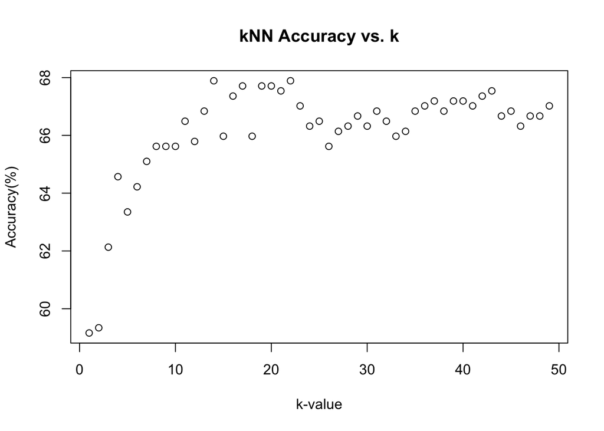

```r
# initialize k and accuracy variables to store the most optimal k value and its accuracy
k_best = 0
a_best = 0

# initialize a dataframe to store the k values and the accuracy to observe trend
df_accuracy <- data.frame(k = integer(), Accuracy = numeric())

# iterate through k values
for (k in 1:49){
  model <- knn(train=train_wotv, test=test_wotv, cl=train_tv, k=k)
  accuracy <- round(sum(model == test_tv)/length(test_tv) *100, 2)
  df_accuracy <- rbind(df_accuracy, data.frame(k = k, Accuracy = accuracy))

  # replace a_best and k_best if accuracy is greater to store most optimal choice
  if (accuracy > a_best){
    a_best <- accuracy
    k_best <- k
  }
}

# plot to see if it is neccessary to test any more k values
plot(df_accuracy$k, df_accuracy$Accuracy,
     xlab = "k-value", ylab = "Accuracy(%)", main = "kNN Accuracy vs. k")
```

According to my code above, the most optimal *k* value is **14** with an accuracy of **67.89%**. As shown in the accuracy plot, performance increases up to a point and then begins to plateau. This suggests that increasing *k* further is unlikely to improve model performance. Therefore, we do not need to test additional *k* values beyond this range. To further evaluate the model, I will examine the confusion matrix to ensure that all categories of the target variable are represented in the predictions and assess class-wise prediction performance.

```r
# examine if all categories are included
model <- knn(train=train_wotv, test=test_wotv, cl=train_tv, k=k_best)
conf_mat2 <- CrossTable(x = test_tv, y = model, prop.chisq = F)
```

```r
kable(conf_mat2$t)
```

|  | Balanced NPK Fertilizer | Compost | DAP | General Purpose Fertilizer | Gypsum | Lime | Muriate of Potash | Organic Fertilizer | Urea | Water Retaining Fertilizer |
| --- | --- | --- | --- | --- | --- | --- | --- | --- | --- | --- |
| Balanced NPK Fertilizer | 26 | 2 | 0 | 0 | 0 | 0 | 0 | 0 | 0 | 2 |
| Compost | 2 | 48 | 7 | 0 | 0 | 3 | 1 | 0 | 0 | 8 |
| DAP | 1 | 3 | 175 | 0 | 0 | 4 | 5 | 2 | 0 | 6 |
| General Purpose Fertilizer | 0 | 1 | 1 | 1 | 0 | 0 | 0 | 1 | 0 | 1 |
| Gypsum | 2 | 2 | 2 | 0 | 2 | 0 | 0 | 0 | 0 | 1 |
| Lime | 0 | 2 | 14 | 0 | 0 | 6 | 1 | 4 | 0 | 6 |
| Muriate of Potash | 0 | 4 | 25 | 0 | 0 | 1 | 17 | 5 | 0 | 7 |
| Organic Fertilizer | 1 | 0 | 4 | 0 | 0 | 1 | 1 | 11 | 0 | 0 |
| Urea | 0 | 0 | 14 | 0 | 0 | 0 | 3 | 0 | 9 | 3 |
| Water Retaining Fertilizer | 13 | 10 | 7 | 0 | 0 | 0 | 4 | 1 | 0 | 90 |

Using the optimal *k* value, the confusion matrix shows that most predictions lie along the diagonal, indicating a good match between actual and predicted labels. However, some categories have notably fewer observations, revealing class imbalance. This imbalance likely contributes to lower predictive accuracy for those underrepresented classes. Additionally, I observed that when *k* exceeds 15, the model fails to predict all categories. This is likely due to over-smoothing, where increasing *k* too much causes the model to generalize excessively, overlooking smaller or less distinct classes. Moving forward, I will be mindful of this behavior to ensure that important patterns in the data are not lost.

## Part F: Validate Model

To perform kNN prediction on the validation data, I must first preprocess the validation set in the same way as the training data. This includes applying the same normalization method, encoding categorical variables consistently, and ensuring the feature set is aligned. This step is crucial to ensure the model interprets the validation data correctly and produces reliable predictions.

### Handle Missing Data

```r
# missing
# View if there are any missing values in the data
num.Rows <- nrow(val_df)
num.Cols <- ncol(val_df)

found <- F

# iterate through numeric columns
for (c in 1:num.Cols){
  missing.Values <- which(is.na(val_df[,c]) | val_df[,c] == "")
  num.Missing.Values <- length(missing.Values)
  if (num.Missing.Values > 0) {
    cat("Column '", names(val_df)[c], "' has ", num.Missing.Values, " missing values")
    found <- T #change found to True if there were misisng values
  }
}
```

```
## Column ' PH ' has  1  missing values
```

```r
if (!found) {
  cat("no missing values detected")
}
```

To handle the missing value, I decided to impute it using the 10% trimmed mean calculated within each group of Crop and Soil type. Given that the validation dataset contains only 200 observations, removing any data points could reduce the representativeness of the data and potentially introduce bias. Imputing within these specific groups helps preserve contextual information while minimizing the influence of outliers.

```r
val_df <- val_df %>%
  group_by(Crop, Soil) %>%
  mutate(
    PH = ifelse(is.na(PH), mean(PH, trim=0.1, na.rm=T), PH)
  ) %>%
  ungroup
```

### Outliers

```r
# Identify outliers
find_outliers(val_df)
```

```
## Found outliers in column ' Rainfall ':
##    -->  350.9135 375.2243
##
## Found outliers in column ' PH ':
##    -->  9.48126 9.512412
```

To find the outliers in the validation dataset, I utilized the function I previously made: `find_outliers()`. The results indicated that there are outliers in the *Rainfall* and *PH* columns. Next, I inspect the data for these columns in further detail to determine how I would like to handle the outliers.

```r
# Rainfall
val_df %>% filter((abs(Rainfall - mean(Rainfall))/sd(Rainfall) > 3))
```

| X | Temperature | Moisture | Rainfall | PH | Nitrogen | Phosphorous | Potassium | Carbon | Soil | Crop |
| --- | --- | --- | --- | --- | --- | --- | --- | --- | --- | --- |
| 1254 | 26.69558 | 0.9723612 | 350.9135 | 4.979770 | 80.63628 | 31.40814 | 62.14377 | 1.956972 | Peaty Soil | Rubber |
| 1261 | 26.79810 | 0.7116611 | 375.2243 | 5.098639 | 90.70351 | 38.09690 | 69.83746 | 1.174409 | Peaty Soil | Rubber |

```r
# PH
val_df %>% filter((abs(PH - mean(PH))/sd(PH) > 3))
```

| X | Temperature | Moisture | Rainfall | PH | Nitrogen | Phosphorous | Potassium | Carbon | Soil | Crop |
| --- | --- | --- | --- | --- | --- | --- | --- | --- | --- | --- |
| 1685 | 28.71254 | 0.5352340 | 56.71577 | 9.481260 | 51.03368 | 21.69314 | 59.04315 | -0.2805600 | Peaty Soil | Moth Beans |
| 1624 | 25.59423 | 0.4396621 | 42.00073 | 9.512412 | 53.56050 | 49.35683 | 38.57777 | 0.8587532 | Peaty Soil | Moth Beans |

```r
val_df %>% group_by(Crop, Soil) %>% filter((abs(Rainfall - mean(Rainfall))/sd(Rainfall) > 3))
```

| X | Temperature | Moisture | Rainfall | PH | Nitrogen | Phosphorous | Potassium | Carbon | Soil | Crop |
| --- | --- | --- | --- | --- | --- | --- | --- | --- | --- | --- |

```r
val_df %>% group_by(Crop, Soil) %>% filter((abs(PH - mean(PH))/sd(PH) > 3))
```

| X | Temperature | Moisture | Rainfall | PH | Nitrogen | Phosphorous | Potassium | Carbon | Soil | Crop |
| --- | --- | --- | --- | --- | --- | --- | --- | --- | --- | --- |

Upon inspecting the outliers, I observed that they consistently appear with the same Soil and Crop types. When I grouped the data by Crop and Soil before identifying outliers, these values no longer appeared as outliers. This suggests that they are not true anomalies but rather valid and meaningful data points within their specific context. Therefore, I will keep these data points for analysis.

### Encoding

I will apply the same encoding methods used for the training dataset.

```r
val_df <- val_df %>%
  # one-hot encoding for Soil
  mutate(
    Loamy_Soil = ifelse(Soil == "Loamy Soil", 1, 0),
    Peaty_Soil = ifelse(Soil == "Peaty Soil", 1, 0),
    Acidic_Soil = ifelse(Soil == "Acidic Soil", 1, 0),
    Neutral_Soil = ifelse(Soil == "Neutral Soil", 1, 0)
  ) %>%

  # Frequency encoding for Crop
  group_by(Crop) %>%
  mutate(CropFreq = n()) %>%
  ungroup()
```

### Scaling Numeric Features

I will now scale the numeric features using the z-score and store the scaled data and the target feature in a new dataframe. I will also add the one-hot encoded categorical feautures afted scaling.

```r
# Create data frame with the columns we want to normalize
val.scaled_df <- val_df %>% select(c(2:9, 16))

# apply z.score_stand function for every column in the train.scaled_df
val.scaled_df <- as.data.frame(lapply(val.scaled_df, z.score_stand))

# add one-hot encoded categorical features into scaled dataframe
val.scaled_df <- val.scaled_df %>%
  mutate(
    Loamy_Soil = val_df$Loamy_Soil,
    Peaty_Soil = val_df$Peaty_Soil,
    Acidic_Soil = val_df$Acidic_Soil,
    Neutral_Soil = val_df$Neutral_Soil,
    Fertilizer = val_df$Fertilizer
  )
```

### Make Prediction

Now that we have shaped the validation data, we can predict the Fertilizer of the data points using the knn model we previously built.

```r
predicted_fertilizer <- knn(train=train_wotv, test=val.scaled_df, cl=train_tv, k=k_best)
```

After predicting the Fertilizer for each data point, we can create a new data frame that includes the observation ID (from the “X” column) along with the predicted Fertilizer category.

```r
val.predicted_df <- data.frame(
  X = val_df$X,
  Fertilizer = predicted_fertilizer
)
```

### Save to CSV file

Lastly, we will save our prediction in a new CSV file.

```r
write.csv(val.predicted_df, "fertilizer-recommendation-validation-predicted.csv", row.names = F)
```